# Experiment 3

2025-07-07

# Descriptive statistics

Percentage of of the answer choices in each condition

| CategoryType | Akira right | Both | Elaine right | Neither |
| --- | --- | --- | --- | --- |
| artifact | 0.19 | 0.21 | 0.57 | 0.03 |
| natural_kind | 0.14 | 0.15 | 0.68 | 0.03 |
| value | 0.25 | 0.30 | 0.41 | 0.04 |

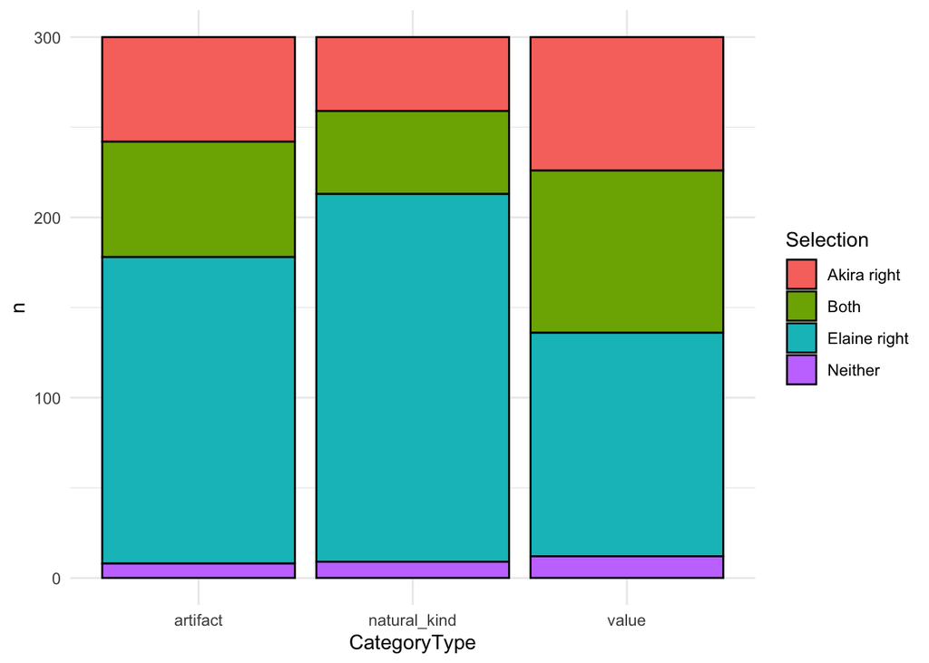

The distribution of selections for each category type

# The results of the model

Model structure: `brm(Selection ~ CategoryType + (CategoryType | Participant) + (1 | item)`

`Selection` had four levels: “Elaine right”,“Akira right”, “Both”, and “Neither”. The model predicted the log-odds of each choice as a function of `CategoryType`.

`CategoryType` had three levels: “Natural”, “Abstract” (Value) and “Artifact”.

`Participant`: There were 50 participants, each with 18 data points total (6 per `CategoryType`). the model included a random slope of category type per participant. This both takes into account the nested structure of the data and allows for the estimation of individual probabilities per `CategoryType`.

This is another simple model that will serve as the model we use for the sensitivity analysis - we should dicuss priors. We can use the data from experiment 2, potentially.

I also want to discuss this experiment to make sure I am understanding it, since we have mostly discussed the first two experiments. I have some data from last year that shows two data files, which I tidied.

| Parameter | Median | CI_low | CI_high | pd | ROPE_Percentage | Rhat | ESS |
| --- | --- | --- | --- | --- | --- | --- | --- |
| b_muBoth_Intercept | -0.09 | -0.63 | 0.44 | 0.62 | 0.51 | 1 | 3166 |
| b_muElaineright_Intercept | 0.89 | 0.24 | 1.52 | 0.99 | 0.00 | 1 | 2327 |
| b_muNeither_Intercept | -6.60 | -7.71 | -5.51 | 1.00 | 0.00 | 1 | 4791 |
| b_muBoth_CategoryTypenatural_kind | -0.15 | -0.74 | 0.42 | 0.70 | 0.45 | 1 | 5486 |
| b_muBoth_CategoryTypevalue | 0.14 | -0.38 | 0.65 | 0.70 | 0.47 | 1 | 4897 |
| b_muElaineright_CategoryTypenatural_kind | 0.40 | -0.40 | 1.21 | 0.84 | 0.22 | 1 | 4476 |
| b_muElaineright_CategoryTypevalue | -0.77 | -1.49 | -0.08 | 0.99 | 0.02 | 1 | 3454 |
| b_muNeither_CategoryTypenatural_kind | 0.67 | -0.22 | 1.59 | 0.93 | 0.12 | 1 | 7407 |
| b_muNeither_CategoryTypevalue | 0.70 | -0.18 | 1.61 | 0.93 | 0.11 | 1 | 5007 |

## The conditional effects based on the model

This plot and table were generated from the model using the `conditional_effects` function in R. The function just does the addition needed and conversion to probability as a convenience.

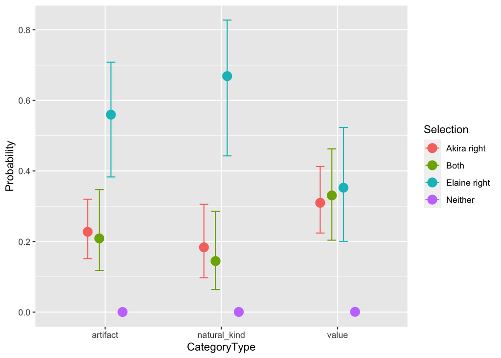

| CategoryType | Akira right | Both | Elaine right | Neither |
| --- | --- | --- | --- | --- |
| artifact | 0.23 [0.15 - 0.32] | 0.21 [0.12 - 0.35] | 0.56 [0.38 - 0.71] | 0 [0 - 0] |
| natural_kind | 0.18 [0.1 - 0.31] | 0.14 [0.06 - 0.29] | 0.67 [0.44 - 0.83] | 0 [0 - 0] |
| value | 0.31 [0.22 - 0.41] | 0.33 [0.2 - 0.46] | 0.35 [0.2 - 0.52] | 0 [0 - 0] |

# Pairwise comparisons

## Elaine is right between answer choices

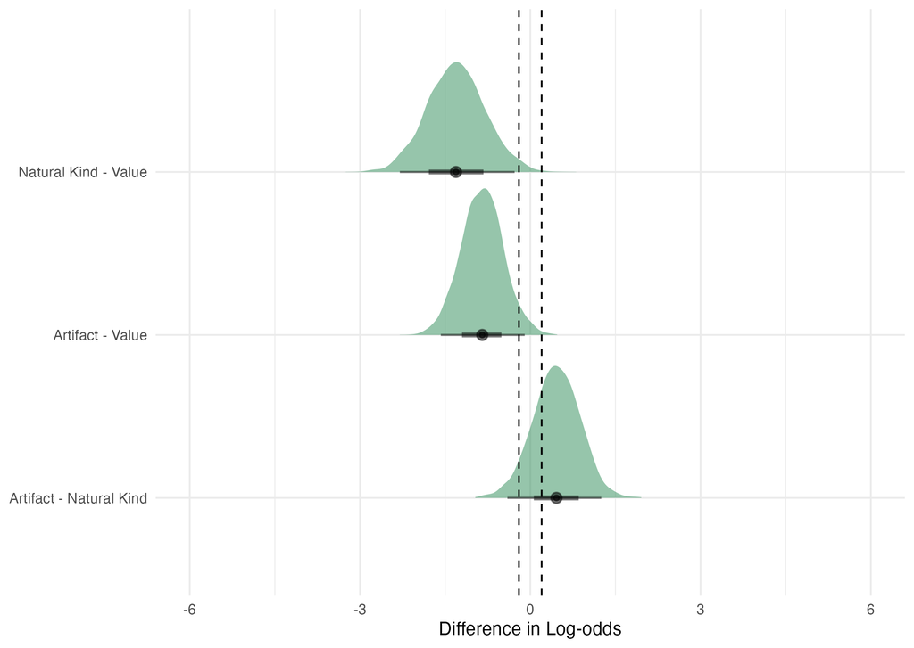

| Comparison | Effect | Compelling_difference |
| --- | --- | --- |
| Elaine right_natural_kind_Elaine right_value | -1.31 [-2.33 - -0.31] | Yes |
| Elaine right_artifact_Elaine right_value | -0.85 [-1.57 - -0.1] | Yes |
| Elaine right_artifact_Elaine right_natural_kind | 0.46 [-0.34 - 1.31] | No |

## Akira is right between answer choices

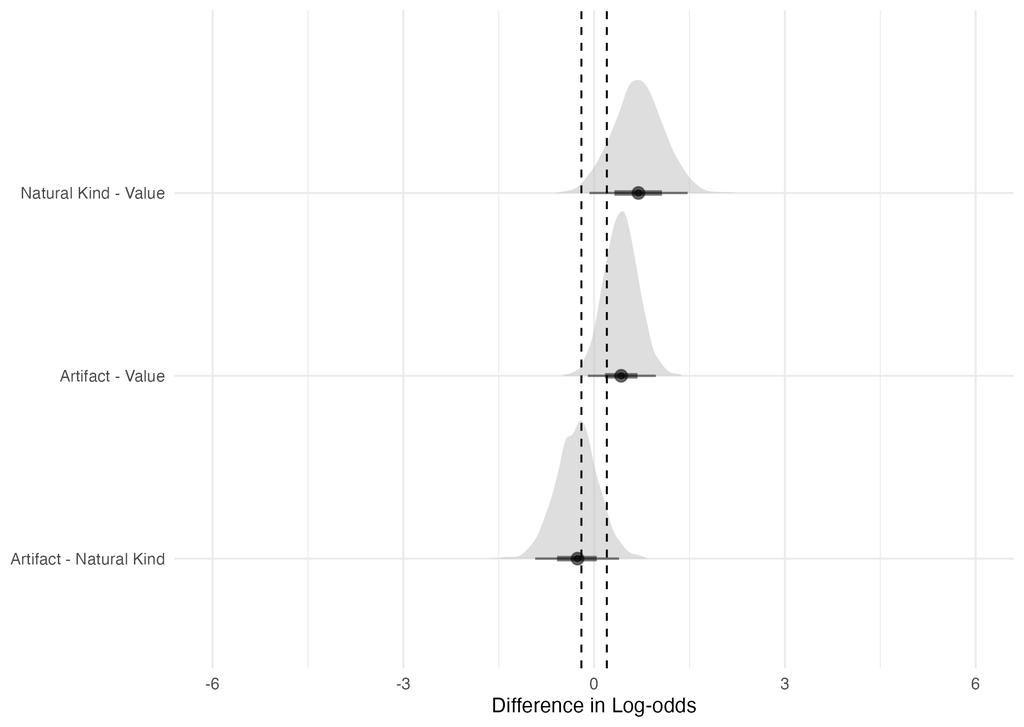

| Comparison | Effect | Compelling_difference |
| --- | --- | --- |
| Akira right_natural_kind_Akira right_value | 0.7 [-0.12 - 1.43] | No |
| Akira right_artifact_Akira right_value | 0.43 [-0.15 - 0.91] | No |
| Akira right_artifact_Akira right_natural_kind | -0.27 [-0.9 - 0.42] | No |

## Both are right is right between answer choices

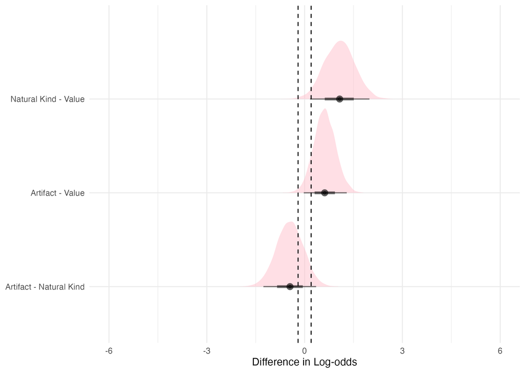

| Comparison | Effect | Compelling_difference |
| --- | --- | --- |
| Both_natural_kind_Both_value | 1.07 [0.14 - 1.95] | Yes |
| Both_artifact_Both_value | 0.62 [-0.05 - 1.26] | No |
| Both_artifact_Both_natural_kind | -0.45 [-1.26 - 0.35] | No |

## Within Natural Kinds

*For these, I left out the pairwise comps with neither, given it was always near 0*

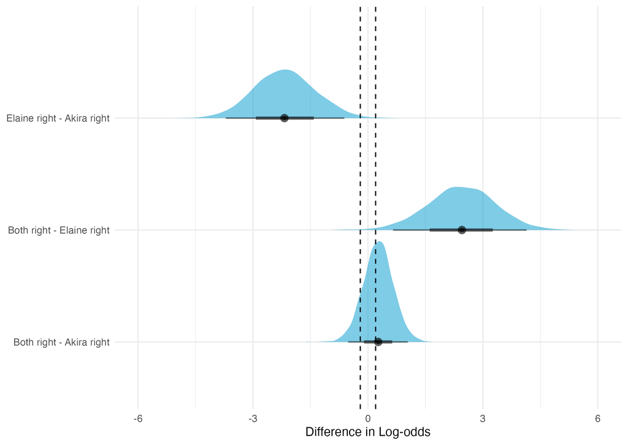

| Comparison | Effect | Compelling_difference |
| --- | --- | --- |
| Elaine right_natural_kind_Akira right_natural_kind | -2.17 [-3.73 - -0.63] | Yes |
| Both_natural_kind_Elaine right_natural_kind | 2.44 [0.6 - 4.08] | Yes |
| Both_natural_kind_Akira right_natural_kind | 0.27 [-0.57 - 0.97] | No |

## Within value

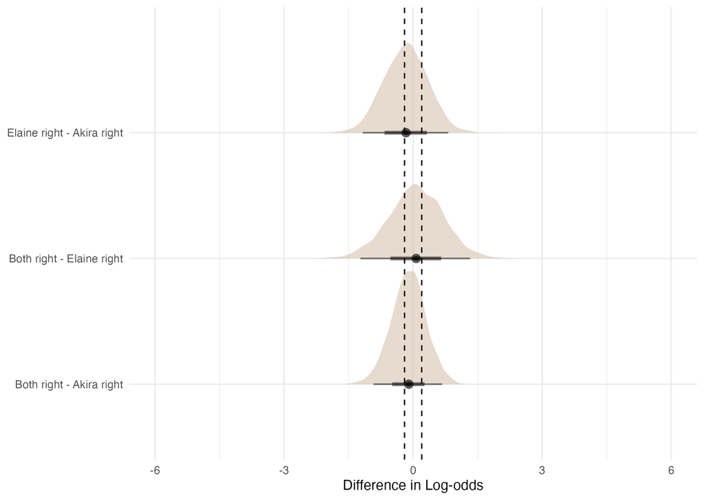

| Comparison | Effect | Compelling_difference |
| --- | --- | --- |
| Elaine right_value_Akira right_value | -0.17 [-1.2 - 0.78] | No |
| Both_value_Elaine right_value | 0.06 [-1.26 - 1.27] | No |
| Both_value_Akira right_value | -0.11 [-0.9 - 0.69] | No |

## Within artifact

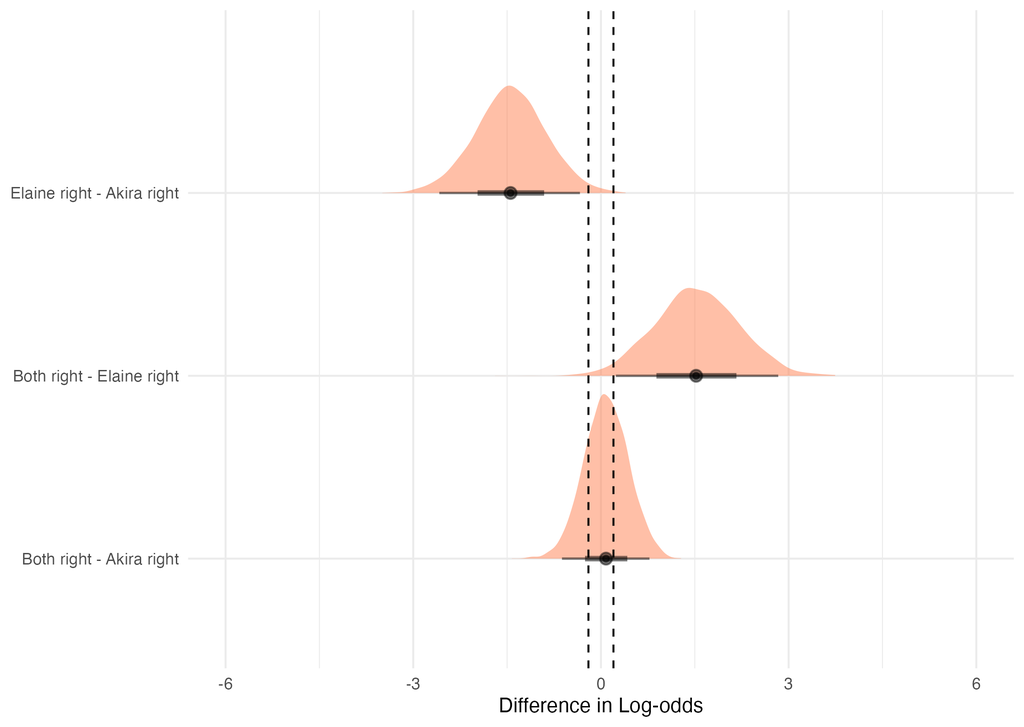

| Comparison | Effect | Compelling_difference |
| --- | --- | --- |
| Elaine right_artifact_Akira right_artifact | -1.45 [-2.55 - -0.32] | Yes |
| Both_artifact_Elaine right_artifact | 1.53 [0.25 - 2.84] | Yes |
| Both_artifact_Akira right_artifact | 0.08 [-0.62 - 0.77] | No |

## Sensitivity Analysis

| Parameter | Median | CI_low | CI_high | pd | ROPE_Percentage | Rhat | ESS |
| --- | --- | --- | --- | --- | --- | --- | --- |
| b_muBoth_Intercept | -0.21 | -0.90 | 0.42 | 0.74 | 0.38 | 1.00 | 1132 |
| b_muElaineright_Intercept | 1.17 | 0.35 | 2.03 | 1.00 | 0.00 | 1.00 | 1268 |
| b_muNeither_Intercept | -2.75 | -4.45 | -1.61 | 1.00 | 0.00 | 1.01 | 717 |
| b_muBoth_CategoryTypenatural_kind | -0.04 | -0.92 | 0.73 | 0.55 | 0.39 | 1.00 | 2107 |
| b_muBoth_CategoryTypevalue | 0.24 | -0.46 | 0.96 | 0.77 | 0.34 | 1.00 | 2190 |
| b_muElaineright_CategoryTypenatural_kind | 1.53 | 0.05 | 3.14 | 0.98 | 0.01 | 1.01 | 1154 |
| b_muElaineright_CategoryTypevalue | -0.73 | -1.91 | 0.42 | 0.90 | 0.10 | 1.01 | 1241 |
| b_muNeither_CategoryTypenatural_kind | 0.52 | -1.27 | 2.16 | 0.74 | 0.15 | 1.00 | 1527 |
| b_muNeither_CategoryTypevalue | 0.21 | -1.47 | 1.89 | 0.62 | 0.19 | 1.01 | 1042 |

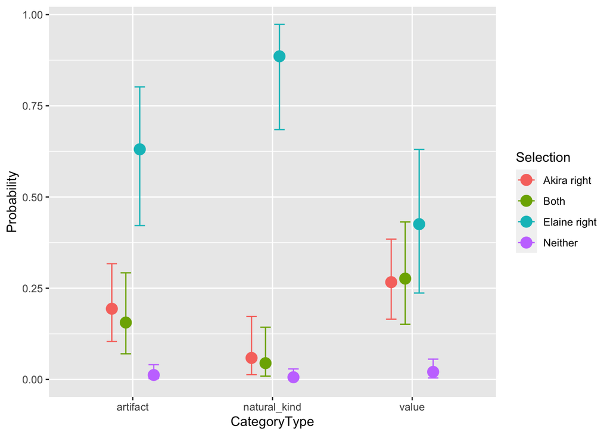

| CategoryType | Akira right | Both | Elaine right | Neither |
| --- | --- | --- | --- | --- |
| artifact | 0.19 [0.1 - 0.32] | 0.16 [0.07 - 0.29] | 0.63 [0.42 - 0.8] | 0.01 [0 - 0.04] |
| natural_kind | 0.06 [0.01 - 0.17] | 0.04 [0.01 - 0.14] | 0.89 [0.68 - 0.97] | 0.01 [0 - 0.03] |
| value | 0.27 [0.17 - 0.38] | 0.28 [0.15 - 0.43] | 0.43 [0.24 - 0.63] | 0.02 [0 - 0.06] |

## Added analysis 7-30-25

**Posterior Predictive Checks for all models**

**Model with default priors PPC**

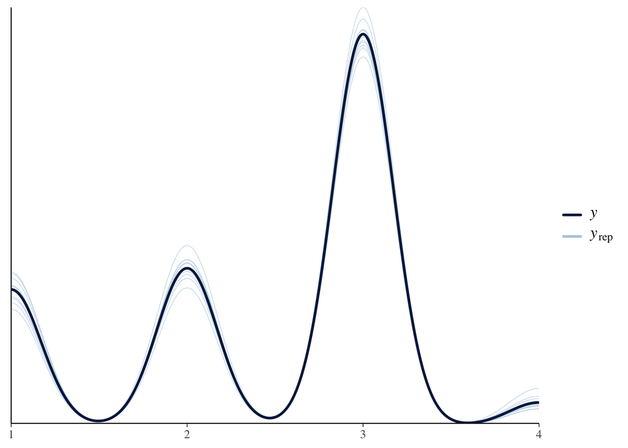

**Model with informed priors PPC**

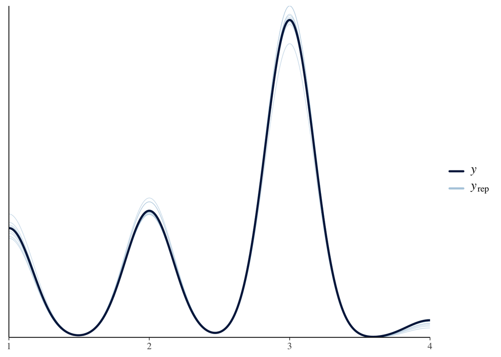

**Comparing model predictions for default and informed prior models**

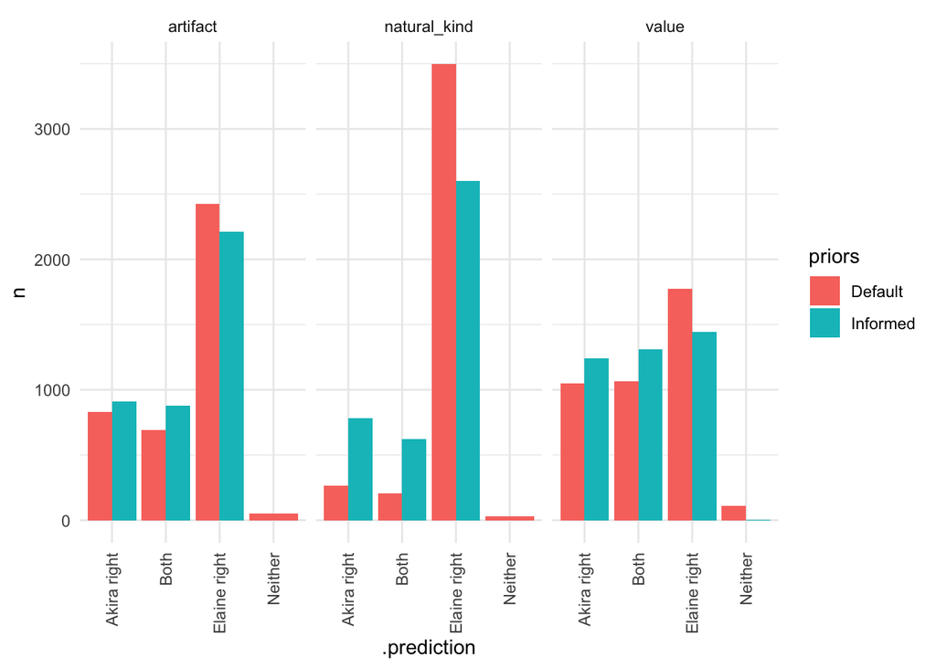

# Pairwise comparisons

## Elaine is right between answer choices **default**

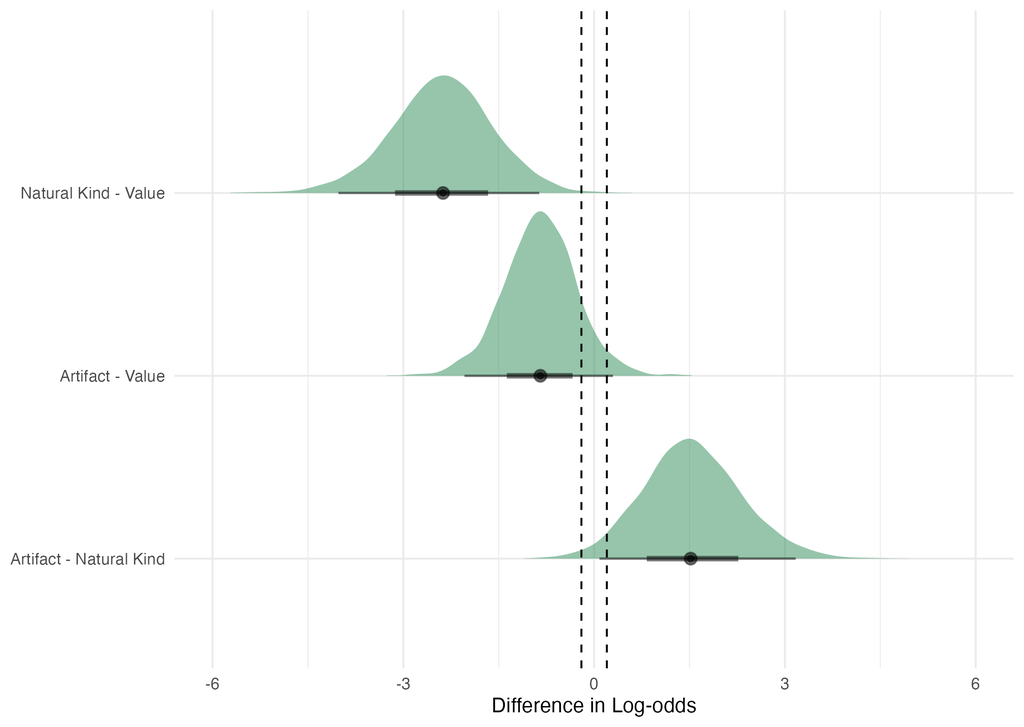

| Comparison | Effect | Compelling_difference |
| --- | --- | --- |
| Elaine right_natural_kind_Elaine right_value | -2.4 [-3.9 - -0.75] | Yes |
| Elaine right_artifact_Elaine right_value | -0.85 [-2.02 - 0.3] | No |
| Elaine right_artifact_Elaine right_natural_kind | 1.55 [0 - 3.07] | Yes |

## Akira is right between answer choices **default**

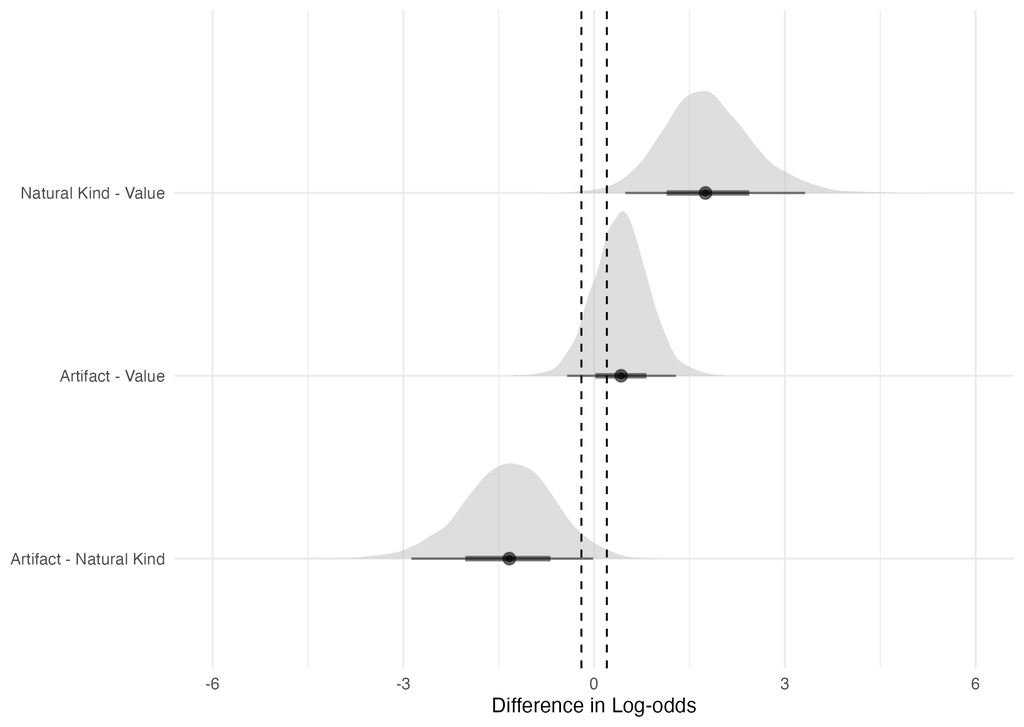

| Comparison | Effect | Compelling_difference |
| --- | --- | --- |
| Akira right_natural_kind_Akira right_value | 1.79 [0.46 - 3.28] | Yes |
| Akira right_artifact_Akira right_value | 0.42 [-0.48 - 1.21] | No |
| Akira right_artifact_Akira right_natural_kind | -1.36 [-2.72 - 0.15] | Yes |

## Both are right is right between answer choices **default**

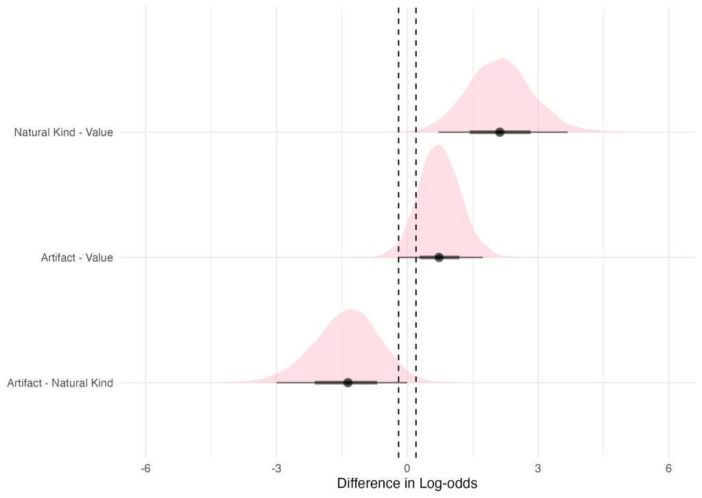

| Comparison | Effect | Compelling_difference |
| --- | --- | --- |
| Both_natural_kind_Both_value | 2.13 [0.63 - 3.56] | Yes |
| Both_artifact_Both_value | 0.73 [-0.18 - 1.75] | No |
| Both_artifact_Both_natural_kind | -1.4 [-3.01 - -0.03] | Yes |

## Within Natural Kinds **default**

*For these, I left out the pairwise comps with neither, given it was always near 0*

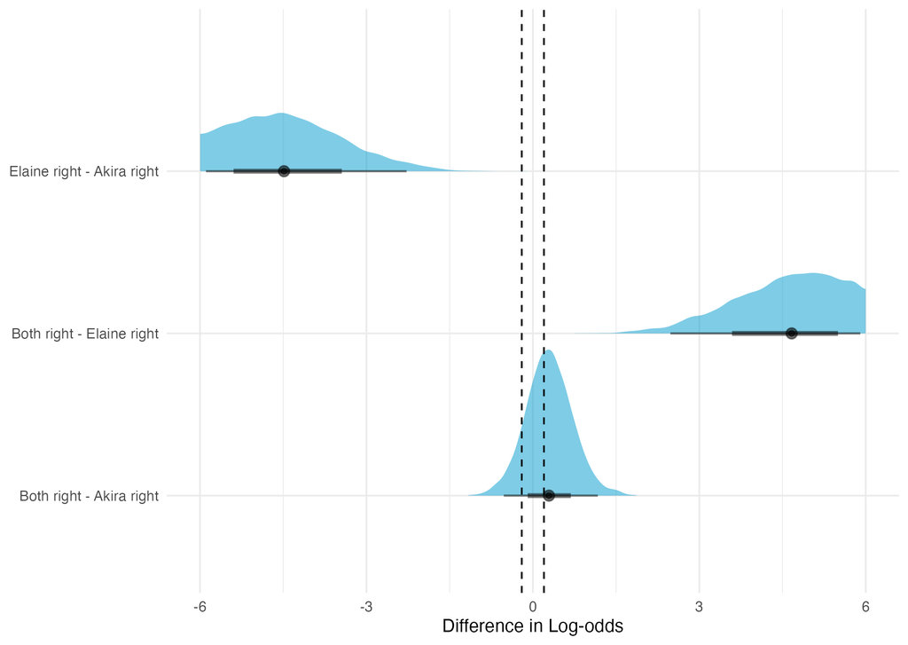

| Comparison | Effect | Compelling_difference |
| --- | --- | --- |
| Elaine right_natural_kind_Akira right_natural_kind | -4.89 [-7.69 - -2.25] | Yes |
| Both_natural_kind_Elaine right_natural_kind | 5.19 [2.56 - 8.11] | Yes |
| Both_natural_kind_Akira right_natural_kind | 0.3 [-0.53 - 1.17] | No |

## Within value **default**

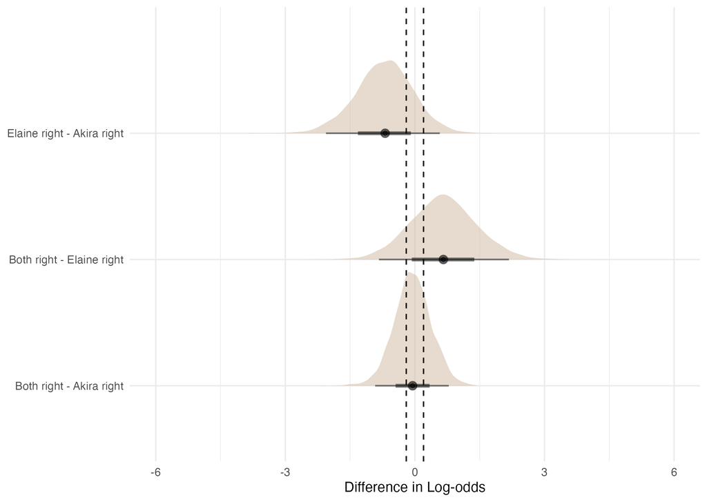

| Comparison | Effect | Compelling_difference |
| --- | --- | --- |
| Elaine right_value_Akira right_value | -0.71 [-2.07 - 0.57] | No |
| Both_value_Elaine right_value | 0.66 [-0.86 - 2.13] | No |
| Both_value_Akira right_value | -0.05 [-0.89 - 0.82] | No |

## Within artifact **default**

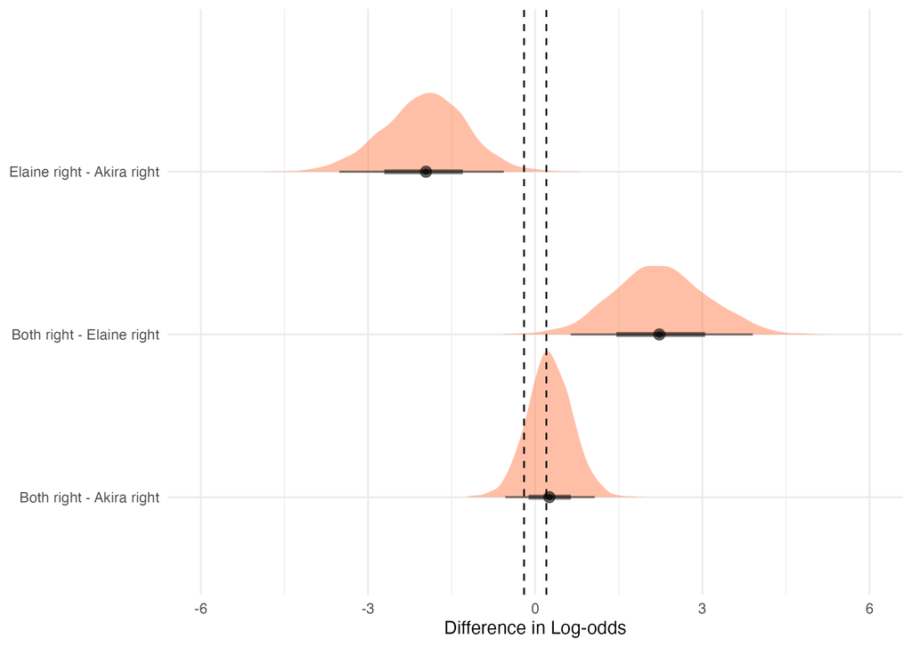

| Comparison | Effect | Compelling_difference |
| --- | --- | --- |
| Elaine right_artifact_Akira right_artifact | -1.98 [-3.5 - -0.55] | Yes |
| Both_artifact_Elaine right_artifact | 2.24 [0.71 - 3.98] | Yes |
| Both_artifact_Akira right_artifact | 0.26 [-0.54 - 1.06] | No |